# Analyzing Individual BGG Users

Phil Henrickson

2022-01-01

# **Coug’s** BoardGameGeek Collection

This notebook contains a set of analyses for the selected user’s boardgamegeek collection. The bulk of the analysis is focused on building a user-specific predictive model to predict the games that Coug is likely to own. This enables to ask questions like, based on the games the user currently owns, what games are a good fit for their collection? What upcoming games are they likely to purchase?

This analysis is based on data from BoardGameGeek that was last updated on **2021-12-20.**

# 1 Collection Overview

We can look at a basic description of the number of games that the user owns, has rated, has previously owned, etc.

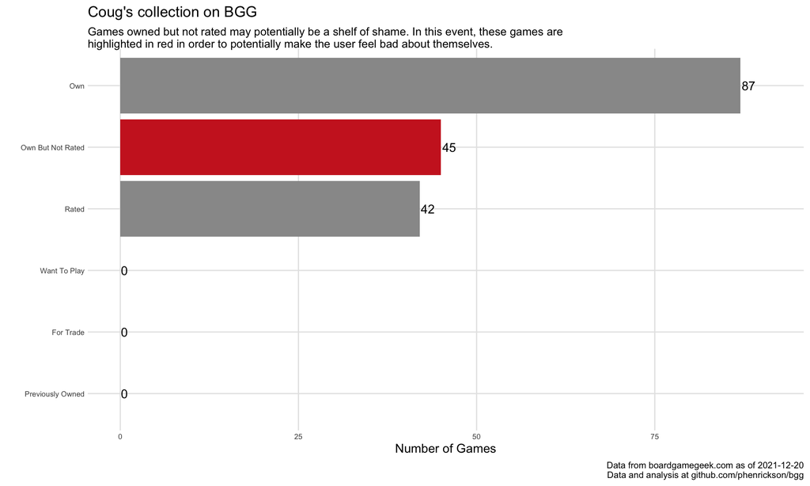

What years has the user owned/rated games from? While we can’t see when a user added or removed a game from their collection, we can look at their collection by the years in which their games were published.

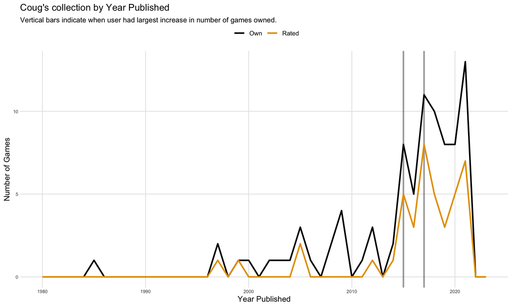

## 1.1 What types of games does Coug own?

We can look at the most frequent types of categories, mechanics, designers, and artists that appear in a user’s collection.

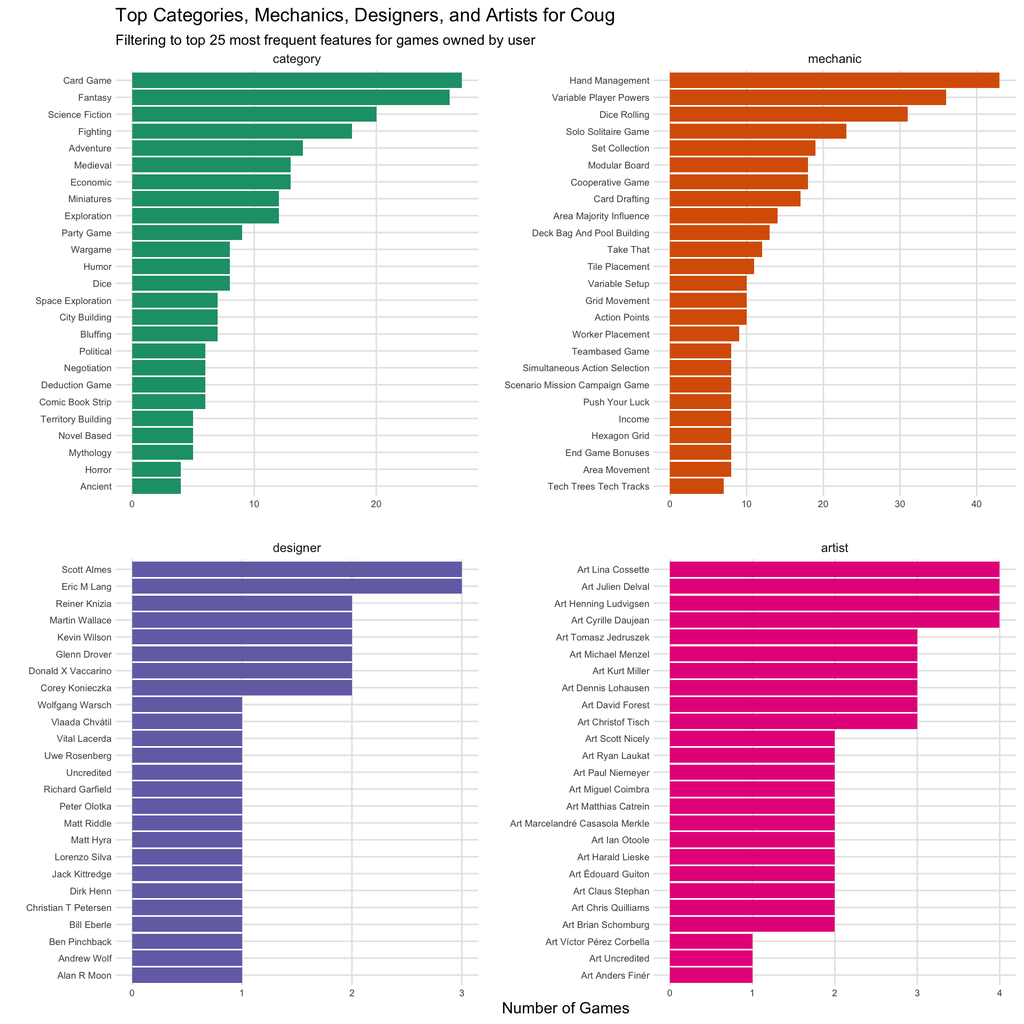

# 2 Modeling **Coug’s** Collection

| username | dataset | period | games_owned | games_rated | games_played |
| --- | --- | --- | --- | --- | --- |
| Coug | training | published before 2020 | 65 | 30 | 65 |
| Coug | test | published 2020 or later | 21 | 12 | 21 |

There are two main (binary) outcomes we will be modeling for the user.

The first, **own** refers to whether the user currently lists a game as owned in their collection. The second, **played** refers to whether the user currently owns, has rated, or previously owned a game. This means the latter will generally have a larger list of games, but may still be a useful category to examine for people who play lots of games without necessarily owning them.

We will train predictive models to learn the probability that the user will own or play individual games based on their features.

## 2.1 Coefficients for Coug

We can examine coefficients from the trained modes, which are penalized logistic regressions fit to our two main outcomes. Positive values indicate that a feature increases a user’s probabilility of owning/rating a game, while negative values indicate a feature decreases the probability.

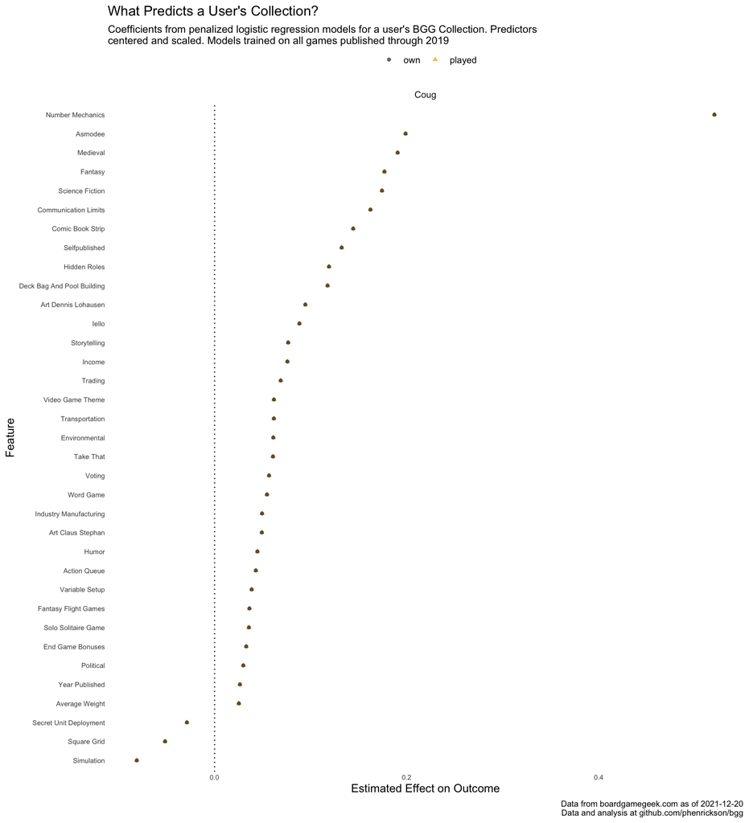

## 2.2 Visualizing Predictors for Coug’s Collection

Why did the model identify these features? We can make density plots of the important features for predicting whether the user owned a game. Blue indicates the density for games owned by the user, while grey indicates the density for games not owned by the user.

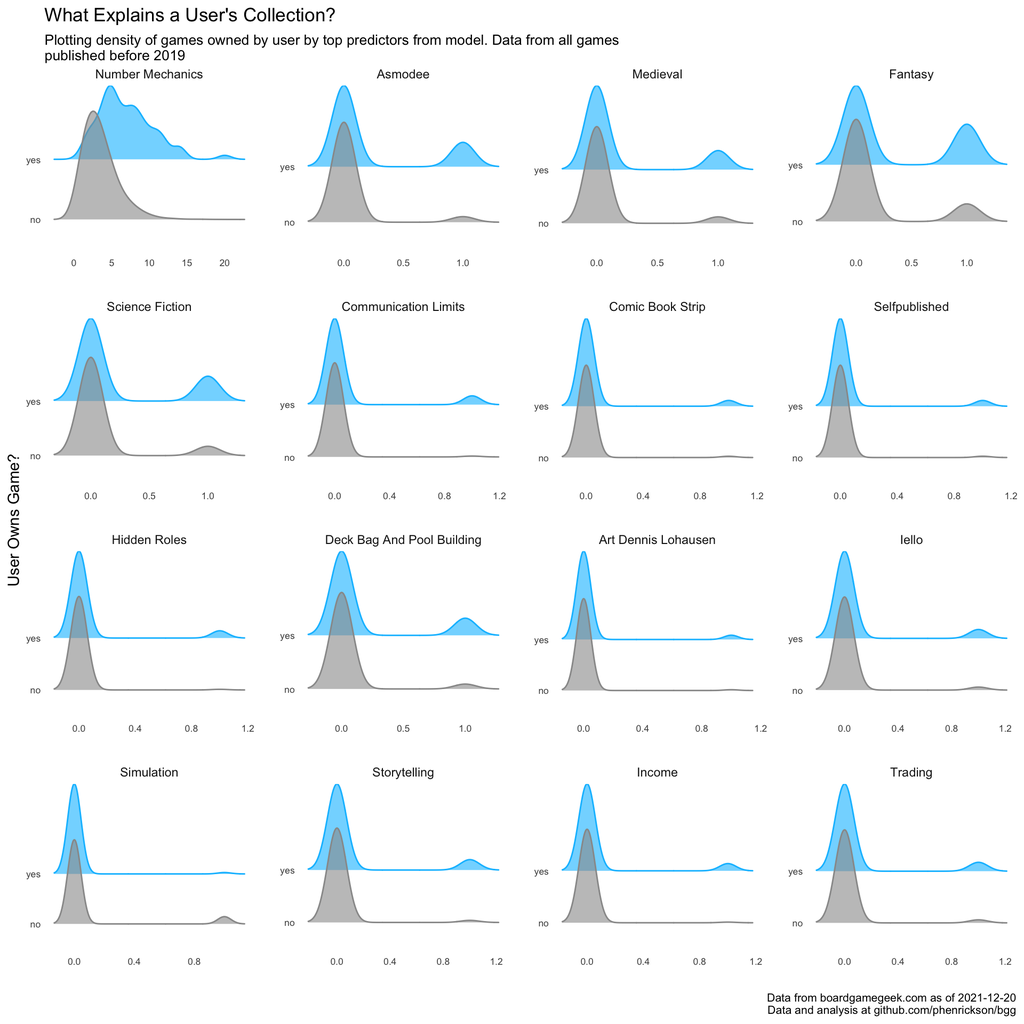

Binary predictors can be difficult to see with this visualization, so we can also directly examine the percentage of games in a user’s collection with a predictor vs the percentage of all games with that predictor.

| username | Feature | % of Games with Feature In_Collection | % of Games with Feature All_Games | Ratio |
| --- | --- | --- | --- | --- |
| Coug | Hidden Roles | 7.7% | 0.7% | 11.3 |
| Coug | Income | 7.7% | 0.7% | 11.3 |
| Coug | Communication Limits | 9.2% | 0.9% | 9.9 |
| Coug | Variable Setup | 12.3% | 1.8% | 6.8 |
| Coug | Storytelling | 10.8% | 2.2% | 5.0 |
| Coug | Comic Book Strip | 6.2% | 1.3% | 4.6 |
| Coug | Asmodee | 23.1% | 5.3% | 4.4 |
| Coug | Selfpublished | 6.2% | 1.4% | 4.4 |
| Coug | Environmental | 4.6% | 1.1% | 4.2 |
| Coug | Voting | 9.2% | 2.4% | 3.9 |
| Coug | Video Game Theme | 6.2% | 1.7% | 3.7 |
| Coug | Action Queue | 9.2% | 2.5% | 3.7 |
| Coug | Deck Bag And Pool Building | 16.9% | 4.8% | 3.5 |
| Coug | Medieval | 18.5% | 6.2% | 3.0 |
| Coug | Iello | 9.2% | 3.1% | 3.0 |
| Coug | Industry Manufacturing | 6.2% | 2.0% | 3.0 |
| Coug | Trading | 9.2% | 3.2% | 2.9 |
| Coug | Science Fiction | 23.1% | 8.6% | 2.7 |
| Coug | Take That | 16.9% | 6.6% | 2.6 |
| Coug | Word Game | 4.6% | 1.8% | 2.6 |
| Coug | Fantasy | 33.8% | 14.7% | 2.3 |
| Coug | Transportation | 6.2% | 2.7% | 2.3 |
| Coug | Humor | 10.8% | 5.6% | 1.9 |
| Coug | Simulation | 1.5% | 7.9% | 0.2 |
| Coug | Square Grid | 0.0% | 1.5% | 0.0 |

# 3 Assess Model’s Performance on Training Set

Before predicting games in upcoming years, we can examine how well the model did and what games it liked in the training set. In this case, we used resampling techniques (cross validation) to ensure that the model had not seen a game before making its predictions.

## 3.1 Separation Plot

An easy way to examine the performance of classification model is to view a separation plot. We plot the predicted probabilities from the model for every game (from resampling) from lowest to highest. We then overlay a blue line for any game that the user does own. A good classifier is one that is able to *separate* the blue (games owned by the user) from the white (games not owned by the user), with most of the blue occurring at the highest probabilities (right side of the chart).

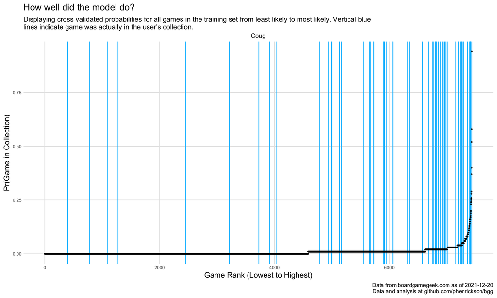

## 3.2 Top Games for **Coug** from Training Set

We can display this information in table form, displaying the 100 games with the highest probability of ownership, adding a blue line when the user does own the game.

| username | yearpublished | game_id | name | pred_played | pred_own | actual_played | actual_own |
| --- | --- | --- | --- | --- | --- | --- | --- |
| Coug | 2017 | 174430 | Gloomhaven | 0.94 | 0.94 | 1 | 1 |
| Coug | 2016 | 198454 | When I Dream | 0.58 | 0.58 | 0 | 0 |
| Coug | 2018 | 205896 | Rising Sun | 0.52 | 0.52 | 0 | 0 |
| Coug | 2017 | 220308 | Gaia Project | 0.40 | 0.40 | 0 | 0 |
| Coug | 2019 | 270971 | Era: Medieval Age | 0.37 | 0.37 | 0 | 0 |
| Coug | 2010 | 62219 | Dominant Species | 0.29 | 0.29 | 0 | 0 |
| Coug | 2012 | 120677 | Terra Mystica | 0.29 | 0.29 | 0 | 0 |
| Coug | 2014 | 164265 | Witness | 0.28 | 0.28 | 0 | 0 |
| Coug | 1995 | 13 | Catan | 0.26 | 0.26 | 0 | 0 |
| Coug | 2005 | 15062 | Shadows over Camelot | 0.26 | 0.26 | 0 | 0 |
| Coug | 2015 | 171623 | The Voyages of Marco Polo | 0.25 | 0.25 | 0 | 0 |
| Coug | 2015 | 175878 | 504 | 0.24 | 0.24 | 0 | 0 |
| Coug | 2016 | 188834 | Secret Hitler | 0.24 | 0.24 | 0 | 0 |
| Coug | 2019 | 253574 | Crusader Kings | 0.24 | 0.24 | 0 | 0 |
| Coug | 2008 | 37111 | Battlestar Galactica: The Board Game | 0.23 | 0.23 | 0 | 0 |
| Coug | 2017 | 218603 | Photosynthesis | 0.20 | 0.20 | 0 | 0 |
| Coug | 2019 | 266507 | Clank!: Legacy – Acquisitions Incorporated | 0.20 | 0.20 | 0 | 0 |
| Coug | 2019 | 257066 | Sierra West | 0.19 | 0.19 | 0 | 0 |
| Coug | 2019 | 285984 | Last Bastion | 0.18 | 0.18 | 0 | 0 |
| Coug | 2016 | 167791 | Terraforming Mars | 0.18 | 0.18 | 1 | 1 |
| Coug | 2011 | 70919 | Takenoko | 0.17 | 0.17 | 0 | 0 |
| Coug | 2018 | 258309 | First Contact | 0.17 | 0.17 | 0 | 0 |
| Coug | 2004 | 9220 | Saboteur | 0.17 | 0.17 | 0 | 0 |
| Coug | 2019 | 269385 | The Lord of the Rings: Journeys in Middle-Earth | 0.17 | 0.17 | 0 | 0 |
| Coug | 2018 | 244711 | Newton | 0.16 | 0.16 | 0 | 0 |
| Coug | 2019 | 264220 | Tainted Grail: The Fall of Avalon | 0.16 | 0.16 | 1 | 1 |
| Coug | 2019 | 276025 | Maracaibo | 0.16 | 0.16 | 0 | 0 |
| Coug | 2018 | 256877 | Hail Hydra | 0.16 | 0.16 | 0 | 0 |
| Coug | 2000 | 478 | Citadels | 0.16 | 0.16 | 1 | 1 |
| Coug | 2014 | 156129 | Deception: Murder in Hong Kong | 0.16 | 0.16 | 1 | 1 |

[output cut: 70 more lines]

We can also more formally assess how well the model did in resampling by looking at the area under the receiver operating characteristic. A perfect model would receive a score of 1, while a model that cannot predict the outcome will default to a score of 0.5. The extent to which something is a *good* score depends on the setting, but generally anything in the .8 to .9 range is very good while the .7 to .8 range is perfectly acceptable.

| username | outcome_type | .metric | .estimator | .estimate |
| --- | --- | --- | --- | --- |
| Coug | own | roc_auc | binary | 0.826 |
| Coug | played | roc_auc | binary | 0.826 |

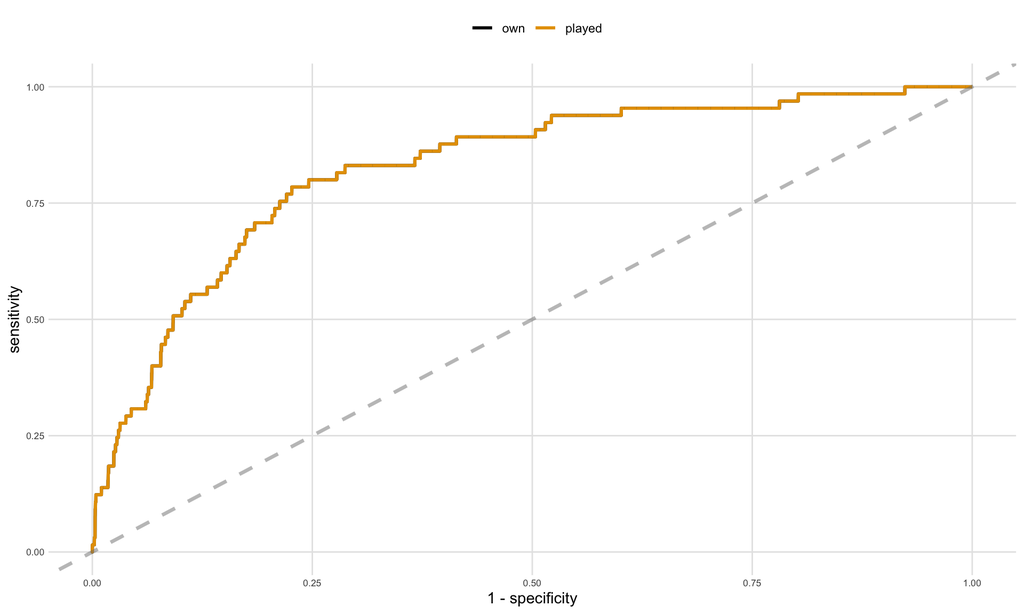

Another way to think about the model performance is to view its lift, or its ability to detect the positive outcomes over that of a null model. High lift indicates the model can much more quickly find all of the positive outcomes (in this case, games owned or played by the user), while a model with no lift is no better than random guessing.

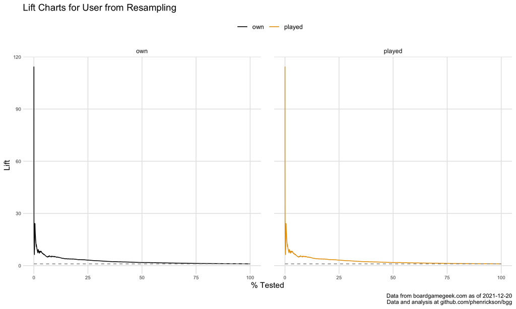

## 3.3 Most and Least Likely Games

What games does the model think Coug is **most likely to own** that are **not** in their collection?

| username | yearpublished | game_id | name | pred_own | actual_own |
| --- | --- | --- | --- | --- | --- |
| Coug | 2016 | 198454 | When I Dream | 0.58 | 0 |
| Coug | 2018 | 205896 | Rising Sun | 0.52 | 0 |
| Coug | 2017 | 220308 | Gaia Project | 0.40 | 0 |
| Coug | 2019 | 270971 | Era: Medieval Age | 0.37 | 0 |
| Coug | 2010 | 62219 | Dominant Species | 0.29 | 0 |

What games does the model think Coug is **least likely to own** that **are** in their collection?

| username | yearpublished | game_id | name | pred_own | actual_own |
| --- | --- | --- | --- | --- | --- |
| Coug | 2015 | 173346 | 7 Wonders Duel | 0 | 1 |
| Coug | 2017 | 202426 | Sidereal Confluence | 0 | 1 |
| Coug | 2005 | 12692 | Gloom | 0 | 1 |
| Coug | 2019 | 253499 | A War of Whispers | 0 | 1 |
| Coug | 2009 | 46213 | Telestrations | 0 | 1 |

## 3.4 Top Games by Year

Top 25 games most likely to be owned by the user in each year, highlighting in blue the games that the user has owned/played.

| rank | 2011 | 2012 | 2013 | 2014 | 2015 | 2016 | 2017 | 2018 | 2019 |
| --- | --- | --- | --- | --- | --- | --- | --- | --- | --- |
| 1 | Takenoko | Terra Mystica | Prosperity | Witness | The Voyages of Marco Polo | When I Dream | Gloomhaven | Rising Sun | Era: Medieval Age |
| 2 | Mage Knight Board Game | Robinson Crusoe: Adventures on the Cursed Island | Lewis & Clark: The Expedition | Deception: Murder in Hong Kong | 504 | Secret Hitler | Gaia Project | First Contact | Crusader Kings |
| 3 | Eclipse | Space Cadets | City of Remnants | Legendary Encounters: An Alien Deck Building Game | Exploding Kittens: NSFW Deck | Terraforming Mars | Photosynthesis | Newton | Clank!: Legacy – Acquisitions Incorporated |
| 4 | Discworld: Ankh-Morpork | Wiz-War (Eighth Edition) | A Study in Emerald | Five Tribes | A Study in Emerald (Second Edition) | A Feast for Odin | Twilight Imperium: Fourth Edition | Hail Hydra | Sierra West |
| 5 | Gears of War: The Board Game | Exodus: Proxima Centauri | Bomb Squad | Spyfall | Runebound (Third Edition) | Exceed Fighting System | Bears vs Babies | Big Trouble in Little China: The Game | Last Bastion |
| 6 | Space Empires: 4X | Archipelago | Forbidden Desert | Ultimate Werewolf | Exploding Kittens | Mansions of Madness: Second Edition | This War of Mine: The Board Game | Renegade | The Lord of the Rings: Journeys in Middle-Earth |
| 7 | A Few Acres of Snow | Keyflower | Mascarade | Sheriff of Nottingham | Blood Rage | Aeon's End | Codenames: Duet | Cosmic Encounter: 42nd Anniversary Edition | Tainted Grail: The Fall of Avalon |
| 8 | Ascension: Return of the Fallen | The Resistance: Avalon | Room 25 | Dead of Winter: A Crossroads Game | Through the Ages: A New Story of Civilization | Codenames: Deep Undercover | Pendragon: The Fall of Roman Britain | Muse: Awakenings | Maracaibo |
| 9 | Village | Smash Up | The Ravens of Thri Sahashri | Machina Arcana | The King Is Dead | Crazy Karts | Spirit Island | The Pirate Republic | Spire's End |
| 10 | Elder Sign | Mice and Mystics | Patchistory | Fields of Arle | T.I.M.E Stories | OrganATTACK! | Dark Souls: The Board Game | Werewords Deluxe Edition | Barrage |
| 11 | The Road to Canterbury | Coup | BANG! The Dice Game | Castles of Mad King Ludwig | Risk: Europe | Citadels | Dinosaur Island | Duelosaur Island | Batman: Gotham City Chronicles |
| 12 | Flash Point: Fire Rescue | Penny Arcade: The Game – Rumble in R'lyeh | Pathfinder Adventure Card Game: Rise of the Runelords – Base Set | DungeonQuest Revised Edition | ...and then, we held hands. | The Oregon Trail Card Game | Magic Maze | Heroes of Terrinoth | The Magnificent |
| 13 | Mansions of Madness | Freedom: The Underground Railroad | The Witches: A Discworld Game | King of New York | Sylvion | Smash Up: It's Your Fault! | Breaking Bad: The Board Game | Gen7: A Crossroads Game | Nanty Narking |
| 14 | Rolling Stock | Kill the Overlord | Glass Road | Spurs: A Tale in the Old West | Burgle Bros. | Inis | Fog of Love | Underwater Cities | Unmatched: Robin Hood vs. Bigfoot |
| 15 | Nightfall | The Great Zimbabwe | Firefly: The Game | Tiny Epic Kingdoms | Bang! The Dice Game: The Walking Dead | Aventuria: Adventure Card Game | Pandemic Legacy: Season 2 | Darklight: Memento Mori | Middara: Unintentional Malum – Act 1 |
| 16 | Dungeon Petz | Descent: Journeys in the Dark (Second Edition) | Gearworld: The Borderlands | Star Realms | One Night Revolution | Forged in Steel | Codenames: Disney – Family Edition | Founders of Gloomhaven | Call to Adventure |
| 17 | Feudalia | Starship Merchants | Duel of Ages II | Arcadia Quest | The Grizzled | Beyond Baker Street | Century: Spice Road | Arkham Horror (Third Edition) | Tiny Epic Mechs |
| 18 | Ninjato | Star Trek Deck Building Game: The Original Series | Eldritch Horror | Abyss | KUNE v LAKIA: A Chronicle Of A Royal Lapine Divorce Foretold | Codenames: Pictures | Too Many Bones | Nemesis | Marco Polo II: In the Service of the Khan |
| 19 | Trollhalla | Spartacus: A Game of Blood and Treachery | Impulse | La Granja | Raptor | New Angeles | Vikings Gone Wild | Everdell | Machina Arcana (Second/Third Edition) |
| 20 | Penny Arcade: The Game – Gamers vs. Evil | Merchant of Venus (Second Edition) | Superfight | Alchemists | Star Realms: Colony Wars | Black Orchestra | Guilds | Luxor | Posthuman Saga |
| 21 | Ascension: Storm of Souls | Rex: Final Days of an Empire | Spyrium | Marrying Mr. Darcy | Inhabit the Earth | Dead of Winter: The Long Night | Pulsar 2849 | Gingerbread House | Arena: The Contest |
| 22 | Tragedy Looper | Libertalia | Metallum | Templar Intrigue | Forge War | Timebomb | A Handful of Stars | Vengeance | Tiny Towns |
| 23 | Chaostle | Dixit: Journey | Smash Up: Awesome Level 9000 | One Night Ultimate Werewolf | Forbidden Stars | Evolution: Climate | Path of Light and Shadow | CO₂: Second Chance | Letter Jam |
| 24 | Dungeon Fighter | Lords of Waterdeep | Smash Up: The Obligatory Cthulhu Set | Heroes Wanted | Dice City | Pandemic: Iberia | Cutthroat Kingdoms | Dawn of Peacemakers | One Key |
| 25 | Mundus Novus | Targi | Batman: Arkham City Escape | Onward to Venus | Mombasa | Scythe | Itchy Feet: the Travel Game | Western Legends | Tapestry |

## 3.5 Interactive Predictions from Resampling

Interactive table for predictions from resampling.

|  | username | yearpublished | rank | game_id | name | pred_played | pred_own | actual_played | actual_own |
| --- | --- | --- | --- | --- | --- | --- | --- | --- | --- |
| 1 | Coug | 1900 | 860 | 2065 | Shogi | 0.01 | 0.01 | 0 | 0 |
| 2 | Coug | 1900 | 1095 | 7316 | Bingo | 0.01 | 0.01 | 0 | 0 |
| 3 | Coug | 1900 | 1626 | 21389 | Happy Families | 0.01 | 0.01 | 0 | 0 |
| 4 | Coug | 1900 | 1919 | 4505 | Tarot | 0.01 | 0.01 | 0 | 0 |
| 5 | Coug | 1900 | 2026 | 5451 | Hanafuda | 0.01 | 0.01 | 0 | 0 |
| 6 | Coug | 1900 | 2034 | 6901 | Euchre | 0.01 | 0.01 | 0 | 0 |
| 7 | Coug | 1900 | 2264 | 45 | Perudo | 0.01 | 0.01 | 0 | 0 |
| 8 | Coug | 1900 | 2275 | 2136 | Pachisi | 0.01 | 0.01 | 0 | 0 |
| 9 | Coug | 1900 | 2405 | 10799 | Old Maid | 0.01 | 0.01 | 0 | 0 |
| 10 | Coug | 1900 | 2420 | 1115 | Poker | 0.01 | 0.01 | 0 | 0 |

[output cut: 7426 more lines]

# 4 Validating the Model on 2020

How well did a model trained on a user’s collection through 2019 perform in predicting games for the user from 2020?

| username | outcome_type | yearpublished | .metric | .estimator | .estimate |
| --- | --- | --- | --- | --- | --- |
| Coug | own | 2020 | roc_auc | binary | 0.879 |
| Coug | played | 2020 | roc_auc | binary | 0.879 |

Table of top 25 games from 2020, highlighting games that the user owns.

| username | yearpublished | game_id | name | pred_own | pred_played | actual_own | actual_played |
| --- | --- | --- | --- | --- | --- | --- | --- |
| Coug | 2020 | 291457 | Gloomhaven: Jaws of the Lion | 0.70 | 0.70 | 1 | 1 |
| Coug | 2020 | 256317 | Guild Master | 0.51 | 0.51 | 0 | 0 |
| Coug | 2020 | 184267 | On Mars | 0.29 | 0.29 | 1 | 1 |
| Coug | 2020 | 292333 | Cowboys II: Cowboys & Indians Edition | 0.19 | 0.19 | 0 | 0 |
| Coug | 2020 | 261403 | Inhuman Conditions | 0.16 | 0.16 | 0 | 0 |
| Coug | 2020 | 302465 | Obsidia | 0.15 | 0.15 | 0 | 0 |
| Coug | 2020 | 246900 | Eclipse: Second Dawn for the Galaxy | 0.13 | 0.13 | 1 | 1 |
| Coug | 2020 | 316554 | Dune: Imperium | 0.13 | 0.13 | 0 | 0 |
| Coug | 2020 | 319966 | The King Is Dead: Second Edition | 0.13 | 0.13 | 0 | 0 |
| Coug | 2020 | 302193 | Wonder Woman: Challenge of the Amazons | 0.12 | 0.12 | 0 | 0 |
| Coug | 2020 | 308765 | Praga Caput Regni | 0.11 | 0.11 | 0 | 0 |
| Coug | 2020 | 323784 | Ghost Letters | 0.11 | 0.11 | 0 | 0 |
| Coug | 2020 | 300322 | Hallertau | 0.09 | 0.09 | 0 | 0 |
| Coug | 2020 | 301767 | Mysterium Park | 0.08 | 0.08 | 0 | 0 |
| Coug | 2020 | 309600 | Archers of Nand | 0.08 | 0.08 | 0 | 0 |
| Coug | 2020 | 313817 | Hello Neighbor: The Secret Neighbor Party Game | 0.07 | 0.07 | 0 | 0 |
| Coug | 2020 | 257145 | Teenage Mutant Ninja Turtles Adventures: City Fall | 0.06 | 0.06 | 0 | 0 |
| Coug | 2020 | 294047 | Superclub | 0.06 | 0.06 | 0 | 0 |
| Coug | 2020 | 295905 | Cosmic Frog | 0.06 | 0.06 | 0 | 0 |
| Coug | 2020 | 296151 | Viscounts of the West Kingdom | 0.06 | 0.06 | 0 | 0 |
| Coug | 2020 | 302723 | Forgotten Waters | 0.06 | 0.06 | 0 | 0 |
| Coug | 2020 | 312965 | Hogs of War: The Miniatures Game | 0.06 | 0.06 | 0 | 0 |
| Coug | 2020 | 313698 | Monster Expedition | 0.06 | 0.06 | 0 | 0 |
| Coug | 2020 | 262274 | D6: Dungeons, Dudes, Dames, Danger, Dice and Dragons! | 0.05 | 0.05 | 0 | 0 |
| Coug | 2020 | 263192 | Teenage Mutant Ninja Turtles Adventures: Change is Constant | 0.05 | 0.05 | 0 | 0 |

# 5 Predicting Upcoming Games (2020 and On) for **Coug**

Examine the top games for the test set.

| username | yearpublished | game_id | name | rank | own | played |
| --- | --- | --- | --- | --- | --- | --- |
| Coug | 2020 | 291457 | Gloomhaven: Jaws of the Lion | 1 | 0.70 | 0.70 |
| Coug | 2020 | 256317 | Guild Master | 2 | 0.51 | 0.51 |
| Coug | 2020 | 184267 | On Mars | 3 | 0.29 | 0.29 |
| Coug | 2020 | 292333 | Cowboys II: Cowboys & Indians Edition | 4 | 0.19 | 0.19 |
| Coug | 2020 | 261403 | Inhuman Conditions | 5 | 0.16 | 0.16 |
| Coug | 2020 | 302465 | Obsidia | 6 | 0.15 | 0.15 |
| Coug | 2020 | 316554 | Dune: Imperium | 7 | 0.13 | 0.13 |
| Coug | 2020 | 246900 | Eclipse: Second Dawn for the Galaxy | 8 | 0.13 | 0.13 |
| Coug | 2020 | 319966 | The King Is Dead: Second Edition | 9 | 0.13 | 0.13 |
| Coug | 2020 | 302193 | Wonder Woman: Challenge of the Amazons | 10 | 0.12 | 0.12 |
| Coug | 2020 | 308765 | Praga Caput Regni | 11 | 0.11 | 0.11 |
| Coug | 2020 | 323784 | Ghost Letters | 12 | 0.11 | 0.11 |
| Coug | 2020 | 300322 | Hallertau | 13 | 0.09 | 0.09 |
| Coug | 2020 | 309600 | Archers of Nand | 14 | 0.08 | 0.08 |
| Coug | 2020 | 301767 | Mysterium Park | 15 | 0.08 | 0.08 |
| Coug | 2020 | 313817 | Hello Neighbor: The Secret Neighbor Party Game | 16 | 0.07 | 0.07 |
| Coug | 2020 | 313698 | Monster Expedition | 17 | 0.06 | 0.06 |
| Coug | 2020 | 295905 | Cosmic Frog | 18 | 0.06 | 0.06 |
| Coug | 2020 | 302723 | Forgotten Waters | 19 | 0.06 | 0.06 |
| Coug | 2020 | 294047 | Superclub | 20 | 0.06 | 0.06 |
| Coug | 2020 | 257145 | Teenage Mutant Ninja Turtles Adventures: City Fall | 21 | 0.06 | 0.06 |
| Coug | 2020 | 296151 | Viscounts of the West Kingdom | 22 | 0.06 | 0.06 |
| Coug | 2020 | 312965 | Hogs of War: The Miniatures Game | 23 | 0.06 | 0.06 |
| Coug | 2020 | 284639 | Gatefall | 24 | 0.05 | 0.05 |
| Coug | 2020 | 310442 | Feierabend | 25 | 0.05 | 0.05 |
| Coug | 2021 | 342942 | Ark Nova | 1 | 0.26 | 0.26 |
| Coug | 2021 | 251661 | Oathsworn: Into the Deepwood | 2 | 0.25 | 0.25 |
| Coug | 2021 | 316287 | Quest | 3 | 0.19 | 0.19 |
| Coug | 2021 | 298102 | Roll Camera!: The Filmmaking Board Game | 4 | 0.17 | 0.17 |
| Coug | 2021 | 310873 | Carnegie | 5 | 0.16 | 0.16 |
| Coug | 2021 | 343905 | Boonlake | 6 | 0.16 | 0.16 |
| Coug | 2021 | 273330 | Bloodborne: The Board Game | 7 | 0.13 | 0.13 |
| Coug | 2021 | 304985 | Dark Ages: Holy Roman Empire | 8 | 0.11 | 0.11 |
| Coug | 2021 | 295535 | Dark Ages: Heritage of Charlemagne | 9 | 0.11 | 0.11 |
| Coug | 2021 | 340466 | Unfathomable | 10 | 0.11 | 0.11 |
| Coug | 2021 | 291572 | Oath: Chronicles of Empire and Exile | 11 | 0.11 | 0.11 |
| Coug | 2021 | 283387 | Rocketmen | 12 | 0.10 | 0.10 |
| Coug | 2021 | 299566 | Batman: The Animated Series Adventures – Shadow of the Bat | 13 | 0.09 | 0.09 |
| Coug | 2021 | 291847 | Mantis Falls | 14 | 0.09 | 0.09 |
| Coug | 2021 | 340237 | Wonder Book | 15 | 0.07 | 0.07 |
| Coug | 2021 | 298383 | Golem | 16 | 0.07 | 0.07 |
| Coug | 2021 | 310100 | Nemesis: Lockdown | 17 | 0.07 | 0.07 |
| Coug | 2021 | 260524 | Beyond Humanity: Colonies | 18 | 0.07 | 0.07 |
| Coug | 2021 | 308989 | Bristol 1350 | 19 | 0.06 | 0.06 |
| Coug | 2021 | 340909 | Gloomholdin' | 20 | 0.06 | 0.06 |
| Coug | 2021 | 295785 | Euthia: Torment of Resurrection | 21 | 0.06 | 0.06 |
| Coug | 2021 | 342848 | World of Warcraft: Wrath of the Lich King | 22 | 0.06 | 0.06 |
| Coug | 2021 | 309250 | Empyrean Hero: The Card Game | 23 | 0.06 | 0.06 |
| Coug | 2021 | 314393 | Wutaki | 24 | 0.05 | 0.05 |
| Coug | 2021 | 331787 | Tiny Epic Dungeons | 25 | 0.05 | 0.05 |
| Coug | 2022 | 295770 | Frosthaven | 1 | 0.51 | 0.51 |
| Coug | 2022 | 331106 | The Witcher: Old World | 2 | 0.45 | 0.45 |
| Coug | 2022 | 283137 | Human Punishment: The Beginning | 3 | 0.20 | 0.20 |
| Coug | 2022 | 322524 | Bardsung | 4 | 0.19 | 0.19 |
| Coug | 2022 | 317511 | Tindaya | 5 | 0.17 | 0.17 |
| Coug | 2022 | 273814 | Deliverance | 6 | 0.08 | 0.08 |
| Coug | 2022 | 317321 | Darkest Dungeon: The Board Game | 7 | 0.08 | 0.08 |
| Coug | 2022 | 256680 | Return to Dark Tower | 8 | 0.07 | 0.07 |
| Coug | 2022 | 319807 | Shogun no Katana | 9 | 0.07 | 0.07 |
| Coug | 2022 | 274471 | Malhya: Lands of Legends | 10 | 0.07 | 0.07 |
| Coug | 2022 | 274124 | Northgard: Uncharted Lands | 11 | 0.06 | 0.06 |
| Coug | 2022 | 271601 | Feed the Kraken | 12 | 0.05 | 0.05 |
| Coug | 2022 | 320718 | Hidden Leaders | 13 | 0.05 | 0.05 |
| Coug | 2022 | 299106 | Fractal: Beyond the Void | 14 | 0.05 | 0.05 |
| Coug | 2022 | 333255 | Keep the Heroes Out! | 15 | 0.04 | 0.04 |
| Coug | 2022 | 311823 | Nova Aetas Renaissance | 16 | 0.04 | 0.04 |
| Coug | 2022 | 316624 | Stationfall | 17 | 0.04 | 0.04 |
| Coug | 2022 | 330950 | Age of Galaxy | 18 | 0.04 | 0.04 |
| Coug | 2022 | 240980 | Blood on the Clocktower | 19 | 0.03 | 0.03 |
| Coug | 2022 | 316915 | U.S.S. Freedom | 20 | 0.03 | 0.03 |
| Coug | 2022 | 344050 | Dubious | 21 | 0.03 | 0.03 |
| Coug | 2022 | 340325 | Vagrantsong | 22 | 0.03 | 0.03 |
| Coug | 2022 | 281647 | Stellaris: Infinite Legacy | 23 | 0.03 | 0.03 |
| Coug | 2022 | 284118 | Mechanical Beast | 24 | 0.03 | 0.03 |
| Coug | 2022 | 325494 | ISS Vanguard | 25 | 0.02 | 0.02 |

## 5.1 Interactive Table for Upcoming Games 2020 and On

|  | username | yearpublished | game_id | name | rank | own | played |
| --- | --- | --- | --- | --- | --- | --- | --- |
| 1 | Coug | 2020 | 291457 | Gloomhaven: Jaws of the Lion | 1 | 0.7 | 0.7 |
| 2 | Coug | 2022 | 295770 | Frosthaven | 2 | 0.51 | 0.51 |
| 3 | Coug | 2020 | 256317 | Guild Master | 3 | 0.51 | 0.51 |
| 4 | Coug | 2022 | 331106 | The Witcher: Old World | 4 | 0.45 | 0.45 |
| 5 | Coug | 2020 | 184267 | On Mars | 5 | 0.29 | 0.29 |
| 6 | Coug | 2021 | 342942 | Ark Nova | 6 | 0.26 | 0.26 |
| 7 | Coug | 2021 | 251661 | Oathsworn: Into the Deepwood | 7 | 0.25 | 0.25 |
| 8 | Coug | 2022 | 283137 | Human Punishment: The Beginning | 8 | 0.2 | 0.2 |
| 9 | Coug | 2021 | 316287 | Quest | 9 | 0.19 | 0.19 |
| 10 | Coug | 2022 | 322524 | Bardsung | 10 | 0.19 | 0.19 |

[output cut: 1627 more lines]